# Introdução

Este relatório tem objetivo de analisar qual modelo é melhor para a predição de fraudes em uma base de transações bancarias. Os modelos analisados foram gerados pelos códigos presentes neste relatório a partir dos algoritmos de aprendizado de máquina:

- Árvore de Decisão
- Rede Neural
- Regressão Logística

Devido ao tempo necessário para criar os modelos eles foram guardados em uma base de dados **SQLite**, esta base se encontra no arquivo **databaseFormodelsCreated.sqlite3** que esta dentro do arquivo compactado que possui o código fonte deste relatório. O arquivo **databaseFormodelsCreated.sqlite3** pode ser aberto e manipulados por programas específicos, como por exemplo o **SQL Lite Studio** que pode ser obtido gratuitamente em https://sqlitestudio.pl/index.rvt.

Uma característica importante sobre a base de dados analisada é que as classes dela estão muito desbalanceadas, mais de 95% das transações da base são da classe legítima, deste modo analisar os modelos com base na acurácia simples não é uma coisa que pode ser feita.

A base de transações bancarias utilizada pode ser encontrada em: https://www.kaggle.com/mlg-ulb/creditcardfraud/home

O código fonte para este relatório pode ser baixado em: https://rebrand.ly/mega-45b02

# Base de dados e algumas informações sobre ela

Carregando base de dados:

```python
import numpy as np
import pandas as pd
import random
df=pd.read_csv('creditcard.csv')
```

Uma amostra da base de dados:

```python
df.head()
```

|  | Time | V1 | V2 | V3 | V4 | V5 | V6 | V7 | V8 | V9 | ... | V21 | V22 | V23 | V24 | V25 | V26 | V27 | V28 | Amount | Class |
| --- | --- | --- | --- | --- | --- | --- | --- | --- | --- | --- | --- | --- | --- | --- | --- | --- | --- | --- | --- | --- | --- |
| 0 | 0.0 | -1.359807 | -0.072781 | 2.536347 | 1.378155 | -0.338321 | 0.462388 | 0.239599 | 0.098698 | 0.363787 | ... | -0.018307 | 0.277838 | -0.110474 | 0.066928 | 0.128539 | -0.189115 | 0.133558 | -0.021053 | 149.62 | 0 |
| 1 | 0.0 | 1.191857 | 0.266151 | 0.166480 | 0.448154 | 0.060018 | -0.082361 | -0.078803 | 0.085102 | -0.255425 | ... | -0.225775 | -0.638672 | 0.101288 | -0.339846 | 0.167170 | 0.125895 | -0.008983 | 0.014724 | 2.69 | 0 |
| 2 | 1.0 | -1.358354 | -1.340163 | 1.773209 | 0.379780 | -0.503198 | 1.800499 | 0.791461 | 0.247676 | -1.514654 | ... | 0.247998 | 0.771679 | 0.909412 | -0.689281 | -0.327642 | -0.139097 | -0.055353 | -0.059752 | 378.66 | 0 |
| 3 | 1.0 | -0.966272 | -0.185226 | 1.792993 | -0.863291 | -0.010309 | 1.247203 | 0.237609 | 0.377436 | -1.387024 | ... | -0.108300 | 0.005274 | -0.190321 | -1.175575 | 0.647376 | -0.221929 | 0.062723 | 0.061458 | 123.50 | 0 |
| 4 | 2.0 | -1.158233 | 0.877737 | 1.548718 | 0.403034 | -0.407193 | 0.095921 | 0.592941 | -0.270533 | 0.817739 | ... | -0.009431 | 0.798278 | -0.137458 | 0.141267 | -0.206010 | 0.502292 | 0.219422 | 0.215153 | 69.99 | 0 |

5 rows × 31 columns

Informações sobre os atributos dos elementos da base de dados:

```python
df.info()
df.describe()
```

```
<class 'pandas.core.frame.DataFrame'>
RangeIndex: 284807 entries, 0 to 284806
Data columns (total 31 columns):
Time      284807 non-null float64
V1        284807 non-null float64
V2        284807 non-null float64
V3        284807 non-null float64
V4        284807 non-null float64
V5        284807 non-null float64
V6        284807 non-null float64
V7        284807 non-null float64
V8        284807 non-null float64
V9        284807 non-null float64
V10       284807 non-null float64
V11       284807 non-null float64
V12       284807 non-null float64
V13       284807 non-null float64
V14       284807 non-null float64
V15       284807 non-null float64
V16       284807 non-null float64
V17       284807 non-null float64
V18       284807 non-null float64
V19       284807 non-null float64
V20       284807 non-null float64
V21       284807 non-null float64
V22       284807 non-null float64
V23       284807 non-null float64
V24       284807 non-null float64
V25       284807 non-null float64
V26       284807 non-null float64
V27       284807 non-null float64
V28       284807 non-null float64
Amount    284807 non-null float64
Class     284807 non-null int64
dtypes: float64(30), int64(1)
memory usage: 67.4 MB
```

|  | Time | V1 | V2 | V3 | V4 | V5 | V6 | V7 | V8 | V9 | ... | V21 | V22 | V23 | V24 | V25 | V26 | V27 | V28 | Amount | Class |
| --- | --- | --- | --- | --- | --- | --- | --- | --- | --- | --- | --- | --- | --- | --- | --- | --- | --- | --- | --- | --- | --- |
| count | 284807.000000 | 2.848070e+05 | 2.848070e+05 | 2.848070e+05 | 2.848070e+05 | 2.848070e+05 | 2.848070e+05 | 2.848070e+05 | 2.848070e+05 | 2.848070e+05 | ... | 2.848070e+05 | 2.848070e+05 | 2.848070e+05 | 2.848070e+05 | 2.848070e+05 | 2.848070e+05 | 2.848070e+05 | 2.848070e+05 | 284807.000000 | 284807.000000 |
| mean | 94813.859575 | 1.165980e-15 | 3.416908e-16 | -1.373150e-15 | 2.086869e-15 | 9.604066e-16 | 1.490107e-15 | -5.556467e-16 | 1.177556e-16 | -2.406455e-15 | ... | 1.656562e-16 | -3.444850e-16 | 2.578648e-16 | 4.471968e-15 | 5.340915e-16 | 1.687098e-15 | -3.666453e-16 | -1.220404e-16 | 88.349619 | 0.001727 |
| std | 47488.145955 | 1.958696e+00 | 1.651309e+00 | 1.516255e+00 | 1.415869e+00 | 1.380247e+00 | 1.332271e+00 | 1.237094e+00 | 1.194353e+00 | 1.098632e+00 | ... | 7.345240e-01 | 7.257016e-01 | 6.244603e-01 | 6.056471e-01 | 5.212781e-01 | 4.822270e-01 | 4.036325e-01 | 3.300833e-01 | 250.120109 | 0.041527 |
| min | 0.000000 | -5.640751e+01 | -7.271573e+01 | -4.832559e+01 | -5.683171e+00 | -1.137433e+02 | -2.616051e+01 | -4.355724e+01 | -7.321672e+01 | -1.343407e+01 | ... | -3.483038e+01 | -1.093314e+01 | -4.480774e+01 | -2.836627e+00 | -1.029540e+01 | -2.604551e+00 | -2.256568e+01 | -1.543008e+01 | 0.000000 | 0.000000 |
| 25% | 54201.500000 | -9.203734e-01 | -5.985499e-01 | -8.903648e-01 | -8.486401e-01 | -6.915971e-01 | -7.682956e-01 | -5.540759e-01 | -2.086297e-01 | -6.430976e-01 | ... | -2.283949e-01 | -5.423504e-01 | -1.618463e-01 | -3.545861e-01 | -3.171451e-01 | -3.269839e-01 | -7.083953e-02 | -5.295979e-02 | 5.600000 | 0.000000 |
| 50% | 84692.000000 | 1.810880e-02 | 6.548556e-02 | 1.798463e-01 | -1.984653e-02 | -5.433583e-02 | -2.741871e-01 | 4.010308e-02 | 2.235804e-02 | -5.142873e-02 | ... | -2.945017e-02 | 6.781943e-03 | -1.119293e-02 | 4.097606e-02 | 1.659350e-02 | -5.213911e-02 | 1.342146e-03 | 1.124383e-02 | 22.000000 | 0.000000 |
| 75% | 139320.500000 | 1.315642e+00 | 8.037239e-01 | 1.027196e+00 | 7.433413e-01 | 6.119264e-01 | 3.985649e-01 | 5.704361e-01 | 3.273459e-01 | 5.971390e-01 | ... | 1.863772e-01 | 5.285536e-01 | 1.476421e-01 | 4.395266e-01 | 3.507156e-01 | 2.409522e-01 | 9.104512e-02 | 7.827995e-02 | 77.165000 | 0.000000 |
| max | 172792.000000 | 2.454930e+00 | 2.205773e+01 | 9.382558e+00 | 1.687534e+01 | 3.480167e+01 | 7.330163e+01 | 1.205895e+02 | 2.000721e+01 | 1.559499e+01 | ... | 2.720284e+01 | 1.050309e+01 | 2.252841e+01 | 4.584549e+00 | 7.519589e+00 | 3.517346e+00 | 3.161220e+01 | 3.384781e+01 | 25691.160000 | 1.000000 |

8 rows × 31 columns

Contagem de dados nulos para os atributos:

```python
df.isnull().sum()
```

```
Time      0
V1        0
V2        0
V3        0
V4        0
V5        0
V6        0
V7        0
V8        0
V9        0
V10       0
V11       0
V12       0
V13       0
V14       0
V15       0
V16       0
V17       0
V18       0
V19       0
V20       0
V21       0
V22       0
V23       0
V24       0
V25       0
V26       0
V27       0
V28       0
Amount    0
Class     0
dtype: int64
```

Colunas utilizadas como entrada para os modelos de previsão:

```python
import numpy as np
columnsWithAttributesToSendToMachineLearningAlgorithm=[]
for i in range(1,29):
    columnsWithAttributesToSendToMachineLearningAlgorithm.append("V"+str(i))
print(columnsWithAttributesToSendToMachineLearningAlgorithm)
```

```
['V1', 'V2', 'V3', 'V4', 'V5', 'V6', 'V7', 'V8', 'V9', 'V10', 'V11', 'V12', 'V13', 'V14', 'V15', 'V16', 'V17', 'V18', 'V19', 'V20', 'V21', 'V22', 'V23', 'V24', 'V25', 'V26', 'V27', 'V28']
```

# Geração e carregamento dos modelos de previsão de fraude

Definições usadas pelos códigos do relatório:

```python
#defines for the models type=================================================
neuralNetworkFromKeras=1
KNNFromScikit=2
decisionThreeFromScikit=3
logisticFromScikit=4
#end=========================================================================

#atributes and class to predict==============================================
Y=df['Class']
X=df[columnsWithAttributesToSendToMachineLearningAlgorithm]
#end=========================================================================

#defines for the class in the data base======================================
classFraud=1
classNotFraud=0
#end=========================================================================
```

```python
from ipywidgets import Checkbox
cb1 = Checkbox(description='Criar novos modelos')
createNewModels=False
def cb1Event(change):
    global createNewModels
    createNewModels=change['new']

cb1.observe(cb1Event, names='value')
display("Marque a caixa de seleção abaixo para apargar os modelos guardados no arquvio databaseFormodelsCreated.sqlite3 e gerar novos modelos.")
display(cb1)
```

```
'Marque a caixa de seleção abaixo para apargar os modelos guardados no arquvio databaseFormodelsCreated.sqlite3 e gerar novos modelos.'
```

## Geração dos modelos

Os modelos criados estão divididos em 3 tipos diferentes de algoritmos de aprendizado de máquina. Doze modelos foram criados utilizando a técnica de validação cruzada para os algoritmos, os modelos foram salvos no arquivo **databaseFormodelsCreated.sqlite3**. A técnica de validação cruzada consiste em dividir a base de dados em K partes (neste caso K=4) e criar K modelos para cada algoritmo de aprendizado máquina, os algoritmos usam em alternância K-1 partes para criar o modelo e uma parte para o teste.

```python
#Code to create neural network models========================================
from sklearn.model_selection import KFold
from sklearn.metrics import confusion_matrix
from sklearn import tree
from sklearn import neighbors
from sklearn import linear_model
import tensorflow as tf
def trainModelsOfTypeKeras(clfFactory,X,Y):
    #clfFactory             => Function to create classifier object
    #X                      => Elements attributes  in dataset
    #Y                      => Elements classes in dataset
    kf = KFold(n_splits=4,shuffle=True,random_state=3223)
    foldsProcessed=0
    vectWithTheTestIndexesForEachFold=[]
    modelsForEachFold=[]
    modelsType=[]
    #parametersToCompileAndFitTheModel===========================================
    parametersForTheModel={
                            "parametersToFit":{"batch_size":100,"class_weight":{0: 1.,1: 50.,},"epochs":1},
                            "parametersToCompile":{ "optimizer":'adam',"loss":'sparse_categorical_crossentropy','metrics':['accuracy']}
    }
    #end=========================================================================

    for train_index, test_index in kf.split(X):
        print("folds processed:"+str(foldsProcessed))
        foldsProcessed=foldsProcessed+1
        X_train  = X.loc[train_index]
        Y_train  = Y[train_index]
        vectWithTheTestIndexesForEachFold.append(test_index)
        clf=clfFactory()

        clf.compile(optimizer=parametersForTheModel["parametersToCompile"]["optimizer"],
                    loss=parametersForTheModel["parametersToCompile"]["loss"],
                    metrics=parametersForTheModel["parametersToCompile"]["metrics"])
        clf.fit(X_train.values,Y_train.values,
                batch_size=parametersForTheModel["parametersToFit"]["batch_size"],
                class_weight=parametersForTheModel["parametersToFit"]["class_weight"],
                epochs=parametersForTheModel["parametersToFit"]["epochs"])
        modelsForEachFold.append(clf)
        modelsType.append(neuralNetworkFromKeras)
    return {
            "vectWithTheTestIndexesForEachFold":vectWithTheTestIndexesForEachFold,
            "modelsForEachFold":modelsForEachFold,
            "parametersForTheModel":parametersForTheModel,
            "modelsType": modelsType
           }

#end=========================================================================

#Code to create others network models========================================
def trainModelsOfTypeScikit(clfFactory,X,Y):
    #clfFactory             => Function to create classifier object
    #X                      => Elements attributes  in dataset
    #Y                      => Elements classes in dataset
    kf = KFold(n_splits=4,shuffle=True,random_state=3223)
    modelsType=[]
    modelsForEachFold=[]
    vectWithTheTestIndexesForEachFold=[]
    for train_index, test_index in kf.split(X):
        X_train  = X.loc[train_index]
        Y_train = Y[train_index]
        clf=clfFactory['constructor'](clfFactory['parameters'])
        clf=clf.fit(X_train,Y_train)
        modelsForEachFold.append(clf)
        vectWithTheTestIndexesForEachFold.append(test_index)
        modelsType.append(clfFactory['modelType'])
    return {
            "vectWithTheTestIndexesForEachFold":vectWithTheTestIndexesForEachFold,
            "modelsForEachFold":modelsForEachFold,
            "parametersForTheModel":clfFactory['parameters'],
            "modelsType": modelsType
    }
#end=========================================================================

#Constructors for the machine learning algorithms============================
kerasModel  = lambda : tf.keras.models.Sequential(    [tf.keras.layers.Dense(units=len(columnsWithAttributesToSendToMachineLearningAlgorithm),activation='relu',input_dim=len(columnsWithAttributesToSendToMachineLearningAlgorithm)),
                                                       tf.keras.layers.Dropout(0.2),
                                                       tf.keras.layers.Dense(16, activation="sigmoid"),
                                                       tf.keras.layers.Dropout(0.2),
                                                       tf.keras.layers.Dense(16, activation="sigmoid"),
                                                       tf.keras.layers.Dropout(0.2),
                                                       tf.keras.layers.Dense(16, activation="sigmoid"),
                                                       tf.keras.layers.Dropout(0.2),
                                                       tf.keras.layers.Dense(16, activation="sigmoid"),
                                                       tf.keras.layers.Dropout(0.2),
                                                       tf.keras.layers.Dense(2, activation=tf.nn.softmax)
                                                      ])
knnFactory  = {"constructor": (lambda parameters: neighbors.KNeighborsClassifier(n_neighbors=parameters['n_neighbors'])),
               "parameters": {'n_neighbors':5},
               "modelType": KNNFromScikit
              }

treeFactory = {"constructor": (lambda parameters: tree.DecisionTreeClassifier()),
               "parameters": {},
               "modelType": decisionThreeFromScikit
              }
linear_modelFactory= {"constructor": (lambda parameters: linear_model.LogisticRegression(solver=parameters['solver'], C=parameters['C'],fit_intercept=parameters['fit_intercept'],max_iter=parameters['max_iter'])),
                      "parameters": {'solver':'saga','C':1.856758,'fit_intercept':False,'max_iter':10000},
                      "modelType": logisticFromScikit
                     }

#end=========================================================================
if(createNewModels):
    trainingSessions=[]
```

Rede Neural

```python
#Execute machine learning algorithms to learn================================
if(createNewModels):
    trainingSessions.append({'modelsTrained':trainModelsOfTypeKeras(kerasModel,X,Y),'description':'Rede Neural'})
#end=========================================================================
```

Árvore de Decisão:

```python
#Execute machine learning algorithms to learn================================
if(createNewModels):
    trainingSessions.append({'modelsTrained':trainModelsOfTypeScikit(treeFactory,X,Y),'description':'Árvore de Decisão'})
#end=========================================================================
```

Regressão Logística:

```python
#Execute machine learning algorithms to learn================================
if(createNewModels):
    trainingSessions.append({'modelsTrained':trainModelsOfTypeScikit(linear_modelFactory,X,Y),'description':'Regressão Logística'})
#end=========================================================================
```

## Salvamento dos modelos em disco

Os modelos vão ser salvos em **databaseFormodelsCreated.sqlite3**

```python
#save models generated and information about them in a sql lite database=====
import sqlite3
import json
import base64
from keras.models import model_from_json, load_model
import pickle
import os
conn = sqlite3.connect('databaseFormodelsCreated.sqlite3')
cur=conn.cursor()
if(createNewModels):
    cur.execute("DELETE FROM model")
    cur.execute("DELETE FROM model_parameters")
    cur.execute("DELETE FROM training_session; ")
    cur.execute("VACUUM;")
    conn.commit()

    for trainingSession in trainingSessions:
        cur.execute('INSERT INTO training_session(description) VALUES(?)',
                    (trainingSession["description"],))

        idForTrainingSession=cur.lastrowid
        setOfModelsTrained=trainingSession['modelsTrained']

        cur.execute('INSERT INTO model_parameters(parameters) VALUES(?)',
                    (json.dumps(setOfModelsTrained["parametersForTheModel"]),))

        idForModelParameters=cur.lastrowid

        for i in range(len(setOfModelsTrained["modelsForEachFold"])):
            modelStoredAtString=""
            if(setOfModelsTrained['modelsType'][i]==neuralNetworkFromKeras):
                setOfModelsTrained["modelsForEachFold"][i].save('tempFileForModel.hdf5')
                fp = open('tempFileForModel.hdf5', 'rb')
                modelStoredAtString=base64.b64encode(fp.read())
                fp.close()
                os.remove('tempFileForModel.hdf5')
            else:
                fp = open('tempFileForModel.sav','wb')
                pickle.dump(setOfModelsTrained["modelsForEachFold"][i], fp)
                fp.close()
                fp = open('tempFileForModel.sav','rb')
                modelStoredAtString=base64.b64encode(fp.read())
                fp.close()
                os.remove('tempFileForModel.sav')

            cur.execute('INSERT INTO model(model_stored_at_base64,model_parameters,vect_with_the_test_indexes_at_dataframe,type,training_session) VALUES(?,?,?,?,?)',
                        (modelStoredAtString,idForModelParameters,json.dumps(list(setOfModelsTrained["vectWithTheTestIndexesForEachFold"][i].data)),setOfModelsTrained["modelsType"][i],idForTrainingSession))

conn.commit()
conn.close()

#end=========================================================================
```

## Carregamento dos modelos

```python
#load models trained=========================================================
import sqlite3
import json
import base64
import pickle
import os
from keras.models import model_from_json, load_model
from keras.initializers import glorot_uniform
from keras.utils import CustomObjectScope
def loadKerasModel(modelStoredAtBase64, parametersToCompileModel):
    #https://stackoverflow.com/questions/53183865/unknown-initializer-glorotuniform-when-loading-keras-model
    modelTrained=None
    with CustomObjectScope({'GlorotUniform': glorot_uniform()}):
        output_file = open('tempFileForModel.hdf5', 'wb')
        output_file.write(base64.b64decode(modelStoredAtBase64))
        output_file.close()
        modelTrained=load_model('tempFileForModel.hdf5')
        modelTrained.compile(optimizer=parametersToCompileModel["optimizer"],
                             loss=parametersToCompileModel["loss"],
                             metrics=parametersToCompileModel["metrics"])
        os.remove('tempFileForModel.hdf5')
    return modelTrained

def loadScikitModel(modelStoredAtBase64):
    fp = open('tempFileForModel.sav', 'wb')
    fp.write(base64.b64decode(modelStoredAtBase64))
    fp.close()
    fp=open('tempFileForModel.sav', 'rb')
    model=pickle.load(fp)
    fp.close()
    os.remove('tempFileForModel.sav')
    return model

conn = sqlite3.connect('databaseFormodelsCreated.sqlite3')
cur=conn.cursor()
trainingSessions=[]
idsForTrainingSessions=[]
descriptionsForTrainingSessions=[]
cur.execute('SELECT id,description FROM training_session  ORDER BY id ASC LIMIT 40')
rows=cur.fetchall()
for row in rows:
    idsForTrainingSessions.append(row[0])
    descriptionsForTrainingSessions.append(row[1])

for i in range(len(idsForTrainingSessions)):
    cur.execute('SELECT mo.model_stored_at_base64, param.parameters, mo.vect_with_the_test_indexes_at_dataframe, mo.type, mo.id, ty.name FROM model as mo  inner join model_parameters as param  on mo.model_parameters =param.id  inner join type_of_model as ty on ty.id=mo.type  where mo.training_session={idForTrainingSession} ORDER BY mo.id  ASC LIMIT 40'.format(idForTrainingSession=idsForTrainingSessions[i]))
    rows = cur.fetchall()
    modelsTrainedLoadedFromDisk=[]
    for row in rows:
        if(row[3]==neuralNetworkFromKeras):
            modelLoaded=loadKerasModel(row[0],json.loads(row[1])['parametersToCompile'])
        else:
            modelLoaded=loadScikitModel(row[0])

        modelsTrainedLoadedFromDisk.append({"modelTrained": modelLoaded, "vectWithTheTestIndexesAtDataFrame":json.loads(row[2]), "type":row[3],'idForModelInDatabase':row[4],'description':row[5]})

    trainingSessions.append({'modelsTrained':modelsTrainedLoadedFromDisk,'description':descriptionsForTrainingSessions[i],'id':idsForTrainingSessions[i]})

conn.close()
#end=========================================================================
```

# Análise dos modelos

Para a análise as transações bancarias foram dívidas em 6 tipos:

- Transações fraudulentas.
- Transações legítimas.
- Transações que são da classe legítima e que o modelo previu como legítimas.
- Transações que são da classe legítima mas que o modelo previu como fraudulentas.
- Transações que são da classe fraudulenta mas que o modelo previu como legítimas.
- Transações que são da classe fraudulenta e que o modelo previu como fraudulentas.

Na linha de cada matriz mostrada a seguir esta um modelo e na coluna esta o tipo de transação. As matrizes mostradas a seguir foram feitas com base nos dados obtidos pelos elementos de testes dos modelos, estes elementos são obtidos da base de dados original (o base guardada no arquivo *.csv).

Para fim de validação um modelo não pode ser testado com um conjunto de dados que tenha elementos que foram usados para treinar o modelo, na validação cruzada (que foi a metodologia utilizada para gerar os modelos) os conjuntos de dados escolhidos para testar um modelo são usados para treinar outro modelo, portanto cada modelo possui conjuntos de testes diferentes. Deste modo a soma das linhas das matrizes a seguir nem sempre vai ser igual.

## Predição das classes da base de dados pelos modelos inferidos

```python
from sklearn.metrics import confusion_matrix
confusion_matricesForEachFoldForModelStoredAtDisk=[]
dfWithPredictedClass=df.copy()
for trainingSession in trainingSessions:
    indexes=[]
    predictedClass=[]
    modelsTrainedLoadedFromDisk=trainingSession['modelsTrained']
    for i in range(len(modelsTrainedLoadedFromDisk)):
        X=df[columnsWithAttributesToSendToMachineLearningAlgorithm].loc[modelsTrainedLoadedFromDisk[i]['vectWithTheTestIndexesAtDataFrame']]
        Y=df['Class'][modelsTrainedLoadedFromDisk[i]['vectWithTheTestIndexesAtDataFrame']]
        predictedClassToModelI=None
        if(modelsTrainedLoadedFromDisk[i]['type']==neuralNetworkFromKeras):
            predictedClassToModelI=list(map(lambda x: 0 if(x[0]>x[1]) else 1,modelsTrainedLoadedFromDisk[i]['modelTrained'].predict(X.values)))
        else:
            predictedClassToModelI=list(modelsTrainedLoadedFromDisk[i]['modelTrained'].predict(X.values))
        indexes=indexes+list(Y.index)
        predictedClass=predictedClass+predictedClassToModelI
        modelsTrainedLoadedFromDisk[i]['confusion_matrix']= confusion_matrix(Y.values,predictedClassToModelI).tolist()

    trainingSession['labelAtDataFrame']='classe predita \n a partir dos modelos \n da sessão de treinamento:\nid='+str(trainingSession['id'])+"\ndescrição="+trainingSession["description"]
    dfWithPredictedClass=pd.concat([pd.DataFrame({trainingSession['labelAtDataFrame']:predictedClass},index=indexes), dfWithPredictedClass], axis=1, sort=False)
```

## Soma da quantia de dinheiro para as transações fraudulentas e não fraudulentas de cada conjunto de teste dos modelos

```python
models=[]
amountClassZeroVet=[]
amountClassOneVet=[]
for trainingSession in trainingSessions:
    for modelTrained in trainingSession['modelsTrained']:
        columWithThePredictedClass=trainingSession['labelAtDataFrame']
        dfTemp=dfWithPredictedClass.loc[modelTrained['vectWithTheTestIndexesAtDataFrame']]
        amountClassZero=sum(dfTemp[dfTemp['Class']==0]['Amount'].values)
        amountClassOne=sum(dfTemp[(dfTemp['Class']==1)]['Amount'].values)
        modelName='modelo id='+str(modelTrained['idForModelInDatabase'])+', descrição="'+modelTrained['description']+'"'
        models.append(modelName)
        amountClassZeroVet.append(amountClassZero)
        amountClassOneVet.append(amountClassOne)
pd.DataFrame({'Transações legítimas':amountClassZeroVet,'Transações fraudulentas':amountClassOneVet}, index=models)
```

|  | Transações fraudulentas | Transações legítimas |
| --- | --- | --- |
| modelo id=717, descrição="Rede Neural" | 13254.82 | 6.250891e+06 |
| modelo id=718, descrição="Rede Neural" | 10634.43 | 6.326643e+06 |
| modelo id=719, descrição="Rede Neural" | 18958.90 | 6.190881e+06 |
| modelo id=720, descrição="Rede Neural" | 17279.82 | 6.334047e+06 |
| modelo id=721, descrição="Arvore de decisao" | 13254.82 | 6.250891e+06 |
| modelo id=722, descrição="Arvore de decisao" | 10634.43 | 6.326643e+06 |
| modelo id=723, descrição="Arvore de decisao" | 18958.90 | 6.190881e+06 |
| modelo id=724, descrição="Arvore de decisao" | 17279.82 | 6.334047e+06 |
| modelo id=725, descrição="Regressão Logística" | 13254.82 | 6.250891e+06 |
| modelo id=726, descrição="Regressão Logística" | 10634.43 | 6.326643e+06 |
| modelo id=727, descrição="Regressão Logística" | 18958.90 | 6.190881e+06 |
| modelo id=728, descrição="Regressão Logística" | 17279.82 | 6.334047e+06 |

```python
get_ipython().run_line_magic('matplotlib', 'inline')
import matplotlib.pyplot as plt
from IPython.display import HTML
import seaborn as sns
for trainingSession in trainingSessions:
    for modelTrained in trainingSession['modelsTrained']:
        columWithThePredictedClass=trainingSession['labelAtDataFrame']
        dfTemp=dfWithPredictedClass.loc[modelTrained['vectWithTheTestIndexesAtDataFrame']]
        f, (ax1, ax2)= plt.subplots(1,2,figsize=(17, 3))
        ax1.set_xlabel("Transações legítimas ")
        ax2.set_xlabel("Transações fraudulentas")
        ax1.hist(dfTemp[dfTemp['Class']==0]['Amount'].values, bins=10)
        ax2.hist(dfTemp[(dfTemp['Class']==1)]['Amount'].values, bins=10)
        display(HTML('modelo id='+str(modelTrained['idForModelInDatabase'])+', descrição="'+modelTrained['description']+'"'))
        plt.show()
        display(HTML("<hr style=\"height: 1px;\">"))
```

[output not shown]

modelo id=717, descrição="Rede Neural"

modelo id=718, descrição="Rede Neural"

modelo id=719, descrição="Rede Neural"

modelo id=720, descrição="Rede Neural"

modelo id=721, descrição="Arvore de decisao"

modelo id=722, descrição="Arvore de decisao"

modelo id=723, descrição="Arvore de decisao"

modelo id=724, descrição="Arvore de decisao"

modelo id=725, descrição="Regressão Logística"

modelo id=726, descrição="Regressão Logística"

modelo id=727, descrição="Regressão Logística"

modelo id=728, descrição="Regressão Logística"

## Análise para quantidade de tipos de transações

```python
columnsForAnalysisOfTransactionsNumber={'Transações legítimas detectadas como legítimas':[],
                                        'Transações legítimas detectadas como fraudulentas':[],
                                        'Transações fraudulentas não detectadas':[],
                                        'Transações fraudulentas detectadas':[]}
indexesForAnalysisOfTransactionsNumber=[]
for trainingSession in trainingSessions:
    for modelTrained in trainingSession['modelsTrained']:
        columnsForAnalysisOfTransactionsNumber['Transações legítimas detectadas como legítimas'].append(modelTrained['confusion_matrix'][0][0])
        columnsForAnalysisOfTransactionsNumber['Transações legítimas detectadas como fraudulentas'].append(modelTrained['confusion_matrix'][0][1])
        columnsForAnalysisOfTransactionsNumber['Transações fraudulentas não detectadas'].append(modelTrained['confusion_matrix'][1][0])
        columnsForAnalysisOfTransactionsNumber['Transações fraudulentas detectadas'].append(modelTrained['confusion_matrix'][1][1])
        indexesForAnalysisOfTransactionsNumber.append('modelo id='+str(modelTrained['idForModelInDatabase'])+', descrição="'+modelTrained['description']+'"')

analyzesAmountOfTransactions=pd.DataFrame(columnsForAnalysisOfTransactionsNumber,index=indexesForAnalysisOfTransactionsNumber)
```

```python
analyzesAmountOfTransactions
```

|  | Transações fraudulentas detectadas | Transações fraudulentas não detectadas | Transações legítimas detectadas como fraudulentas | Transações legítimas detectadas como legítimas |
| --- | --- | --- | --- | --- |
| modelo id=717, descrição="Rede Neural" | 84 | 31 | 17 | 71070 |
| modelo id=718, descrição="Rede Neural" | 105 | 21 | 17 | 71059 |
| modelo id=719, descrição="Rede Neural" | 111 | 26 | 16 | 71049 |
| modelo id=720, descrição="Rede Neural" | 93 | 21 | 18 | 71069 |
| modelo id=721, descrição="Arvore de decisao" | 76 | 39 | 28 | 71059 |
| modelo id=722, descrição="Arvore de decisao" | 90 | 36 | 34 | 71042 |
| modelo id=723, descrição="Arvore de decisao" | 108 | 29 | 27 | 71038 |
| modelo id=724, descrição="Arvore de decisao" | 87 | 27 | 16 | 71071 |
| modelo id=725, descrição="Regressão Logística" | 87 | 28 | 47 | 71040 |
| modelo id=726, descrição="Regressão Logística" | 100 | 26 | 38 | 71038 |
| modelo id=727, descrição="Regressão Logística" | 114 | 23 | 30 | 71035 |
| modelo id=728, descrição="Regressão Logística" | 93 | 21 | 26 | 71061 |

## Análise para quantidade de dinheiro movimentado pelos tipos de transações

### Matriz mostrando a quantidade de dinheiro movimentado pelos tipos de transações

```python
columnsForAnalysisOfTransactionsMoney={'Transações legítimas detectadas como legítimas':[],
                                       'Transações legítimas detectadas como fraudulentas':[],
                                       'Transações fraudulentas não detectadas':[],
                                       'Transações fraudulentas detectadas':[]}

indexesForAnalysisOfTransactionsNumber=[]
for trainingSession in trainingSessions:
    for modelTrained in trainingSession['modelsTrained']:
        dfTemp=dfWithPredictedClass.loc[modelTrained['vectWithTheTestIndexesAtDataFrame']]
        columWithThePredictedClass=trainingSession['labelAtDataFrame']
        columnsForAnalysisOfTransactionsMoney['Transações legítimas detectadas como legítimas'].append(sum(dfTemp[(dfTemp[columWithThePredictedClass]==0) & (dfTemp['Class']==0)]['Amount']))
        columnsForAnalysisOfTransactionsMoney['Transações legítimas detectadas como fraudulentas'].append(sum(dfTemp[(dfTemp[columWithThePredictedClass]==1) & (dfTemp['Class']==0)]['Amount']))
        columnsForAnalysisOfTransactionsMoney['Transações fraudulentas não detectadas'].append(sum(dfTemp[(dfTemp[columWithThePredictedClass]==0) & (dfTemp['Class']==1)]['Amount']))
        columnsForAnalysisOfTransactionsMoney['Transações fraudulentas detectadas'].append(sum(dfTemp[(dfTemp[columWithThePredictedClass]==1) & (dfTemp['Class']==1)]['Amount']))
        indexesForAnalysisOfTransactionsNumber.append('modelo id='+str(modelTrained['idForModelInDatabase'])+', descrição="'+modelTrained['description']+'"')


analyzesAmountOfMoneyFromTransactions=pd.DataFrame(columnsForAnalysisOfTransactionsMoney,
                                                   index=indexesForAnalysisOfTransactionsNumber,
                                                   columns=['Transações legítimas detectadas como legítimas',
                                                            'Transações legítimas detectadas como fraudulentas',
                                                            'Transações fraudulentas não detectadas',
                                                            'Transações fraudulentas detectadas'])
analyzesAmountOfMoneyFromTransactions
```

|  | Transações legítimas detectadas como legítimas | Transações legítimas detectadas como fraudulentas | Transações fraudulentas não detectadas | Transações fraudulentas detectadas |
| --- | --- | --- | --- | --- |
| modelo id=717, descrição="Rede Neural" | 6.250213e+06 | 678.19 | 5946.56 | 7308.26 |
| modelo id=718, descrição="Rede Neural" | 6.326005e+06 | 638.50 | 2183.47 | 8450.96 |
| modelo id=719, descrição="Rede Neural" | 6.190044e+06 | 836.99 | 5076.75 | 13882.15 |
| modelo id=720, descrição="Rede Neural" | 6.331907e+06 | 2139.95 | 6459.76 | 10820.06 |
| modelo id=721, descrição="Arvore de decisao" | 6.248522e+06 | 2368.62 | 6862.05 | 6392.77 |
| modelo id=722, descrição="Arvore de decisao" | 6.319907e+06 | 6736.79 | 3173.82 | 7460.61 |
| modelo id=723, descrição="Arvore de decisao" | 6.185086e+06 | 5795.14 | 5515.56 | 13443.34 |
| modelo id=724, descrição="Arvore de decisao" | 6.329658e+06 | 4388.34 | 5187.54 | 12092.28 |
| modelo id=725, descrição="Regressão Logística" | 6.239796e+06 | 11094.45 | 4579.20 | 8675.62 |
| modelo id=726, descrição="Regressão Logística" | 6.307183e+06 | 19460.10 | 2172.29 | 8462.14 |
| modelo id=727, descrição="Regressão Logística" | 6.182842e+06 | 8038.71 | 2899.87 | 16059.03 |
| modelo id=728, descrição="Regressão Logística" | 6.319741e+06 | 14306.01 | 4600.79 | 12679.03 |

### Matriz com a proporção de dinheiro movimentado pelos tipos de transações

```python
columnsForAnalysisOfTransactionsMoneyProp={'Transações legítimas detectadas como legítimas':[],
                                       'Transações legítimas detectadas como fraudulentas':[],
                                       'Transações fraudulentas não detectadas':[],
                                       'Transações fraudulentas detectadas':[]}

for i in range(len(indexesForAnalysisOfTransactionsNumber)):
    totalMoney=0.0
    for column in columnsForAnalysisOfTransactionsMoneyProp.keys():
        totalMoney=totalMoney+columnsForAnalysisOfTransactionsMoney[column][i]

    for column in columnsForAnalysisOfTransactionsMoneyProp.keys():
        columnsForAnalysisOfTransactionsMoneyProp[column].append("{:4.4f}%".format((columnsForAnalysisOfTransactionsMoney[column][i]/totalMoney)*100.0))


analyzesAmountOfMoneyFromTransactionsProp=pd.DataFrame(columnsForAnalysisOfTransactionsMoneyProp,
                                                       index=indexesForAnalysisOfTransactionsNumber,
                                                       columns=['Transações legítimas detectadas como legítimas',
                                                                'Transações legítimas detectadas como fraudulentas',
                                                                'Transações fraudulentas não detectadas',
                                                                'Transações fraudulentas detectadas'])

analyzesAmountOfMoneyFromTransactionsProp
```

|  | Transações legítimas detectadas como legítimas | Transações legítimas detectadas como fraudulentas | Transações fraudulentas não detectadas | Transações fraudulentas detectadas |
| --- | --- | --- | --- | --- |
| modelo id=717, descrição="Rede Neural" | 99.7776% | 0.0108% | 0.0949% | 0.1167% |
| modelo id=718, descrição="Rede Neural" | 99.8221% | 0.0101% | 0.0345% | 0.1334% |
| modelo id=719, descrição="Rede Neural" | 99.6812% | 0.0135% | 0.0818% | 0.2236% |
| modelo id=720, descrição="Rede Neural" | 99.6942% | 0.0337% | 0.1017% | 0.1704% |
| modelo id=721, descrição="Arvore de decisao" | 99.7506% | 0.0378% | 0.1095% | 0.1021% |
| modelo id=722, descrição="Arvore de decisao" | 99.7259% | 0.1063% | 0.0501% | 0.1177% |
| modelo id=723, descrição="Arvore de decisao" | 99.6014% | 0.0933% | 0.0888% | 0.2165% |
| modelo id=724, descrição="Arvore de decisao" | 99.6588% | 0.0691% | 0.0817% | 0.1904% |
| modelo id=725, descrição="Regressão Logística" | 99.6113% | 0.1771% | 0.0731% | 0.1385% |
| modelo id=726, descrição="Regressão Logística" | 99.5251% | 0.3071% | 0.0343% | 0.1335% |
| modelo id=727, descrição="Regressão Logística" | 99.5652% | 0.1295% | 0.0467% | 0.2586% |
| modelo id=728, descrição="Regressão Logística" | 99.5027% | 0.2252% | 0.0724% | 0.1996% |

### Histogramas mostrando a quantidade de dinheiro movimentado pelos tipos de transações para cada modelo

modelo id=717, descrição="Rede Neural"

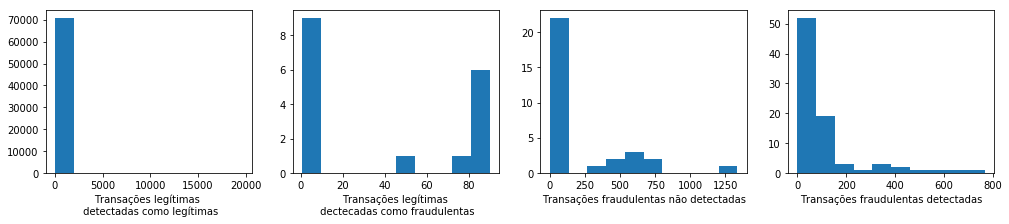

modelo id=718, descrição="Rede Neural"

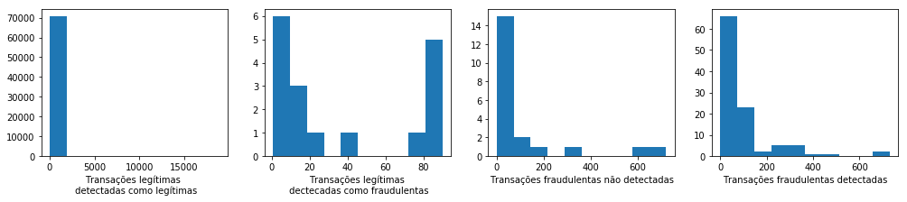

modelo id=719, descrição="Rede Neural"

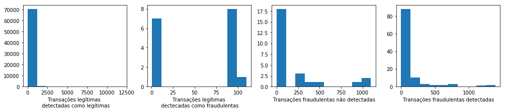

modelo id=720, descrição="Rede Neural"

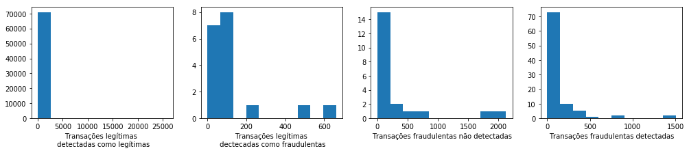

modelo id=721, descrição="Arvore de decisao"

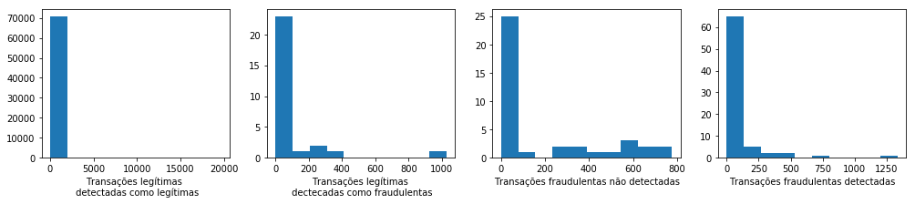

modelo id=722, descrição="Arvore de decisao"

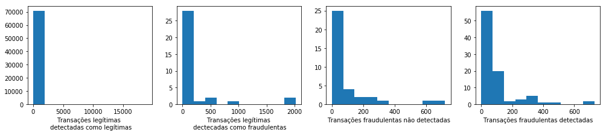

modelo id=723, descrição="Arvore de decisao"

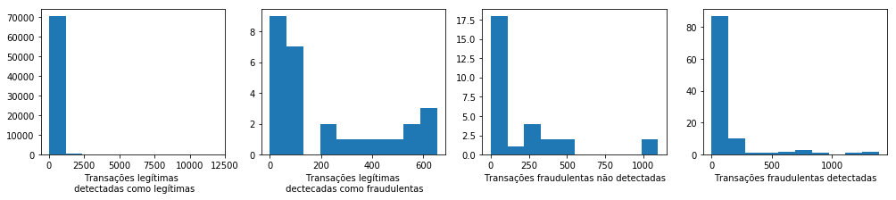

modelo id=724, descrição="Arvore de decisao"

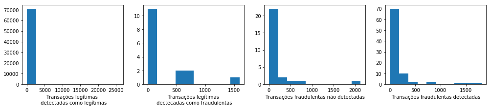

modelo id=725, descrição="Regressão Logística"

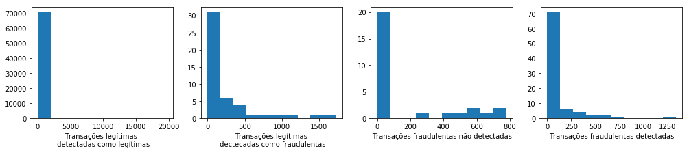

modelo id=726, descrição="Regressão Logística"

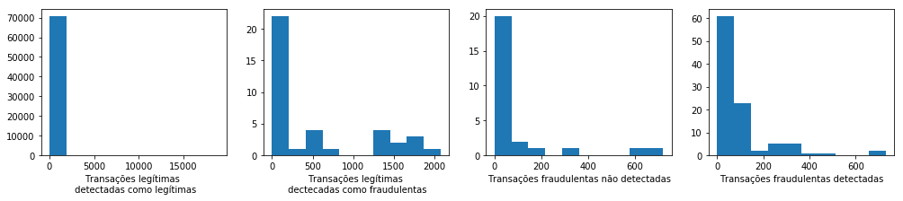

modelo id=727, descrição="Regressão Logística"

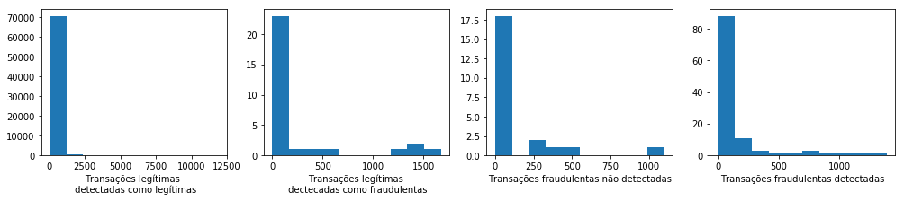

modelo id=728, descrição="Regressão Logística"

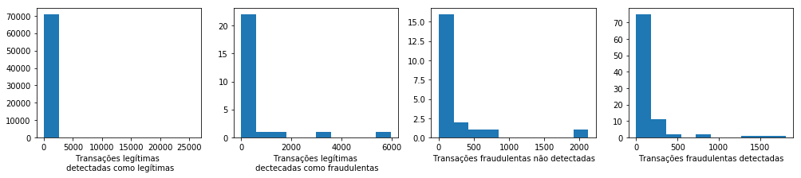

```python
get_ipython().run_line_magic('matplotlib', 'inline')
from IPython.display import HTML
import matplotlib.pyplot as plt
for trainingSession in trainingSessions:
    for modelTrained in trainingSession['modelsTrained']:
        columWithThePredictedClass=trainingSession['labelAtDataFrame']
        dfTemp=dfWithPredictedClass.loc[modelTrained['vectWithTheTestIndexesAtDataFrame']]
        f, (ax1, ax2,ax3,ax4)= plt.subplots(1,4,figsize=(17, 3))
        ax1.set_xlabel("Transações legítimas \n detectadas como legítimas")
        ax2.set_xlabel("Transações legítimas \n dectecadas como fraudulentas")
        ax3.set_xlabel("Transações fraudulentas não detectadas")
        ax4.set_xlabel("Transações fraudulentas detectadas")
        ax1.hist(dfTemp[(dfTemp[columWithThePredictedClass]==0) & (dfTemp['Class']==0)]['Amount'].values, bins=10)
        ax2.hist(dfTemp[(dfTemp[columWithThePredictedClass]==1) & (dfTemp['Class']==0)]['Amount'].values, bins=10)
        ax3.hist(dfTemp[(dfTemp[columWithThePredictedClass]==0) & (dfTemp['Class']==1)]['Amount'].values, bins=10)
        ax4.hist(dfTemp[(dfTemp[columWithThePredictedClass]==1) & (dfTemp['Class']==1)]['Amount'].values, bins=10)
        display(HTML('modelo id='+str(modelTrained['idForModelInDatabase'])+', descrição="'+modelTrained['description']+'"'))
        plt.show()
        display(HTML("<hr style=\"height: 1px;\">"))
```

### Análise dos dados obtidos para a escolha do modelo de previsão

Observando os dados levantados com relação os modelos de previsão pode-se concluir que o melhor modelo de previsão é o com id igual a 718, os motivos para esta escolha são:

- A quantidade de transações fraudulentas não detectadas é a mais baixa que existe. Este fato por ser observado na Subseção **Análise para quantidade de tipos de transações**
- A quantidade de dinheiro a ser bloqueado pelo modelo por este achar de forma errada que a transação era fraudulenta quando na verdade era legítima também é a mais baixa que existe. Este fato por ser observado na Subseção **Matriz mostrando a quantidade de dinheiro movimentado pelos tipos de transações**.
- A quantidade de dinheiro movimentado por transações fraudulentas não detectadas pela modelo também é a segunda mais baixa que existe. Este fato por ser observado também na Subseção **Matriz mostrando a quantidade de dinheiro movimentado pelos tipos de transações**.
- As transações que o modelo bloquearia erroneamente, por achar que transação era fraudulenta quando na verdade era legitima, são transações de baixo valor. Por serem de baixo valor estes bloqueios causariam poucos transtornos para os envolvidos nas transações, os envolvidos poderiam realizar a transação por outra forma de pagamento (como por exemplo dinheiro em espécie). Este dado por ser observado na Subseção **Histogramas mostrando a quantidade de dinheiro movimentado pelos tipos de transações para cada modelo**.

Um detalhe importante foi que ao analisar os modelos gerados, utilizando como critérios de análise os motivos apresentados antes, os modelos de predição baseados em rede neural são os que apresentam os melhores resultados.

# Conclusão

Este relatorio analisou modelos de predição de fraudes em transações bancarias, estes modelos foram gerados pelos códigos de programa presentes no relatorio e guardados em um arquivo com extensão **sqllite3**. Dentro dos modelos analizados os do tipo rede neural são os que apresentaram melhores resultados, com destaque para o modelo com o id 718.